# Homework 3

Author: Matthew J. Crossley

Last update: 04 May, 2024

## Learning objectives

- Cultivate and demonstrate a deep understanding of how to build biologically plausible models of brain networks using Izhikevich neurons.

## General instructions

- When I say ‘show that blah blah blah’ in the problems below, I mean replicate the plots. Or get close enough to replication that I can see that you understand how to program the basal ganglia and also that you understand the qualitative patterns that I’m trying to highlight.

## Key features of the basal ganglia

- The **direct pathway** of the basal ganglia is: Cerebral cortex (ctx) $\rightarrow$ striatum (str) $\rightarrow$ internal segment of the globus pallidus (gpi) $\rightarrow$ thalamus (thl) $\rightarrow$ cerebral cortex (ctx). The striatal cells on this pathway contain D1 dopamine receptors so we may abbreviate them d1 instead of str.
- The **indirect pathway** of the basal ganglia is: Cerebral cortex (ctx) $\rightarrow$ striatum (str) $\rightarrow$ external segment of the globus pallidus (gpe) $\rightarrow$ internal segment of the globus pallidus (gpi) $\rightarrow$ thalamus (thl) $\rightarrow$ cerebral cortex (ctx). The striatal cells on this pathway contain d2 dopamine receptors so we may abbreviate them d2 instead of str.
- The **hyperdirect pathway** of the basal ganglia is: Cerebral cortex (ctx) $\rightarrow$ subthalamic nucleus $\rightarrow$ internal segment of the globus pallidus (gpi) $\rightarrow$ thalamus (thl) $\rightarrow$ cerebral cortex (ctx).
- Both segments of the globus pallidus have high baseline firing rates (they fire a high frequency train of action potentials even in the absence of excitatory inputs).

## 0

- Striatal cells (d1 and d2 cells) have interesting elecrophysiological properties, so they are deserving of a special set of izhikevich model parameters. Every other cells in the network can be modeled with a regular spiking neuron. Please use the following parameters for these two neuron types:

```python
# # striatal projection neuron
# C = 50; vr = -80; vt = -25; vpeak = 40;
# a = 0.01; b = -20; c = -55; d = 150; k = 1;

# # regular spiking neuron
# C = 100; vr = -60; vt = -40; vpeak = 35;
# a = 0.03; b = -2; c = -50; d = 100; k = 0.7;
```

- Show how the d1 and d2 cells in the striatum respond to current differently from a regular spiking neuron.

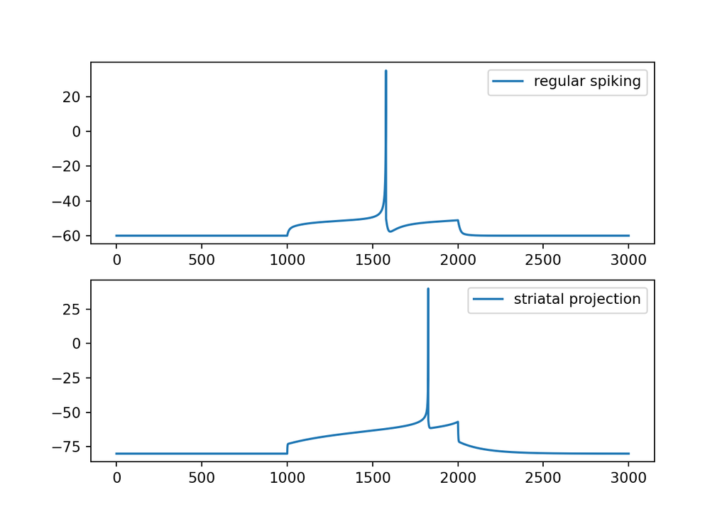

## Helper function

```python
import numpy as np
import matplotlib.pyplot as plt


def sim_bg(I_in, w_in):

    # response of each spike on post synaptic membrane v
    psp_amp = 1e3
    psp_decay = 100

    # allocate memory for each neuron
    v = np.zeros((n_cells, n_steps))
    u = np.zeros((n_cells, n_steps))
    g = np.zeros((n_cells, n_steps))
    spike = np.zeros((n_cells, n_steps))
    v[:, 0] = iz_params[:, 1] + np.random.rand(n_cells) * 100

    # connection weight matrix
    w = np.zeros((n_cells, n_cells))

    # direct pathway
    w[0, 1] = 1 * 100
    w[1, 3] = -1 * 125

    # indirect pathway
    w[0, 2] = 1 * 100
    w[2, 4] = -1 * 100
    w[4, 3] = -1 * 25

    # hyperdirect pathway
    w[0, 6] = 1 * 90
    w[6, 3] = 1 * 50

    # stn-gpe feedback
    w[6, 4] = 1
    w[4, 6] = -1 * 50

    # output
    w[3, 5] = -1 * 100
    w[5, 0] = 1

    # input into cells from other cells
    I_net = np.zeros((n_cells, n_steps))

    for i in range(1, n_steps):

        dt = t[i] - t[i - 1]

        I_net = np.zeros((n_cells, n_steps))
        for jj in range(n_cells):
            for kk in range(n_cells):
                if jj != kk:
                    I_net[jj, i - 1] += w[kk, jj] * g[kk, i - 1]

            I_net[jj, i - 1] += w_in[jj] * I_in[i - 1]

            C = iz_params[jj, 0]
            vr = iz_params[jj, 1]
            vt = iz_params[jj, 2]
            vpeak = iz_params[jj, 3]
            a = iz_params[jj, 4]
            b = iz_params[jj, 5]
            c = iz_params[jj, 6]
            d = iz_params[jj, 7]
            k = iz_params[jj, 8]

            dvdt = (k * (v[jj, i - 1] - vr) * (v[jj, i - 1] - vt) -
                    u[jj, i - 1] + I_net[jj, i - 1] + E[jj]) / C
            dudt = a * (b * (v[jj, i - 1] - vr) - u[jj, i - 1])
            dgdt = (-g[jj, i - 1] + psp_amp * spike[jj, i - 1]) / psp_decay

            v[jj, i] = v[jj, i - 1] + dvdt * dt
            u[jj, i] = u[jj, i - 1] + dudt * dt
            g[jj, i] = g[jj, i - 1] + dgdt * dt

            if v[jj, i] >= vpeak:
                v[jj, i - 1] = vpeak
                v[jj, i] = c
                u[jj, i] = u[jj, i] + d
                spike[jj, i] = 1

    fig, ax = plt.subplots(3, 4, squeeze=False)
    # ctx
    ax[1, 0].set_title('ctx')
    ax1 = ax[1, 0]
    ax2 = ax1.twinx()
    ax1.plot(t, v[0, :], 'C0')
    ax2.plot(t, g[0, :], 'C1')
    # stn
    ax[0, 1].set_title('stn')
    ax1 = ax[0, 1]
    ax2 = ax1.twinx()
    ax1.plot(t, v[6, :], 'C0')  # stn
    ax2.plot(t, g[6, :], 'C1')  # stn
    # d1
    ax[1, 1].set_title('d1')
    ax1 = ax[1, 1]
    ax2 = ax1.twinx()
    ax1.plot(t, v[1, :], 'C0')  # d1
    ax2.plot(t, g[1, :], 'C1')  # d1
    # d2
    ax[2, 1].set_title('d2')
    ax1 = ax[2, 1]
    ax2 = ax1.twinx()
    ax1.plot(t, v[2, :], 'C0')  # d2
    ax2.plot(t, g[2, :], 'C1')  # d2
    # gpi
    ax[1, 2].set_title('gpi')
    ax1 = ax[1, 2]
    ax2 = ax1.twinx()
    ax1.plot(t, v[3, :], 'C0')  # gpi
    ax2.plot(t, g[3, :], 'C1')  # gpi
    # gpe
    ax[2, 2].set_title('gpe')
    ax1 = ax[2, 2]
    ax2 = ax1.twinx()
    ax1.plot(t, v[4, :], 'C0')  # gpe
    ax2.plot(t, g[4, :], 'C1')  # gpe
    # thal
    ax[1, 3].set_title('thal')
    ax1 = ax[1, 3]
    ax2 = ax1.twinx()
    ax1.plot(t, v[5, :], 'C0')  # thal
    ax2.plot(t, g[5, :], 'C1')  # thal
    plt.tight_layout()
    plt.show()
```

## Helper init code

```python
tau = 0.1
T = 3000
t = np.arange(0, T, tau)
n_steps = t.shape[0]

# Cells: CTX, D1, D2, GPi, GPe, Thal, STN
# Direct: CTX -> D1 -> GPi
# Indirect: CTX -> D2 -> GPe -> GPi
# Hyperdirect: CTX -> STN -> GPi
# Output: GPi -> Thal -> CTX
# Gain limiter: STN <-> GPe

# # striatal projection neuron
# C = 50; vr = -80; vt = -25; vpeak = 40;
# a = 0.01; b = -20; c = -55; d = 150; k = 1;

# # regular spiking neuron
# C = 100; vr = -60; vt = -40; vpeak = 35;
# a = 0.03; b = -2; c = -50; d = 100; k = 0.7;

iz_params = np.array([
    [100, -60, -40, 35, 0.03, -2, -50, 100, 0.7],  # ctx (rs) 0
    [50, -80, -25, 40, 0.01, -20, -55, 150, 1],  # d1 (spn) 1
    [50, -80, -25, 40, 0.01, -20, -55, 150, 1],  # d2 (spn) 2
    [100, -60, -40, 35, 0.03, -2, -50, 100, 0.7],  # gpi (rs) 3
    [100, -60, -40, 35, 0.03, -2, -50, 100, 0.7],  # gpe (rs) 4
    [100, -60, -40, 35, 0.03, -2, -50, 100, 0.7],  # thal (rs) 5
    [100, -60, -40, 35, 0.03, -2, -50, 100, 0.7]  # stn (rs) 6
])

# baseline firing (high for GPi, GPe, and thal)
E = np.array([0, 0, 0, 300, 300, 300, 0])

n_cells = iz_params.shape[0]
```

## 1

- Show that increasing drive through the direct pathway reduces inhibition of the thalamus and therefore may be seen as a ‘go’ pathway.

### low d1 input

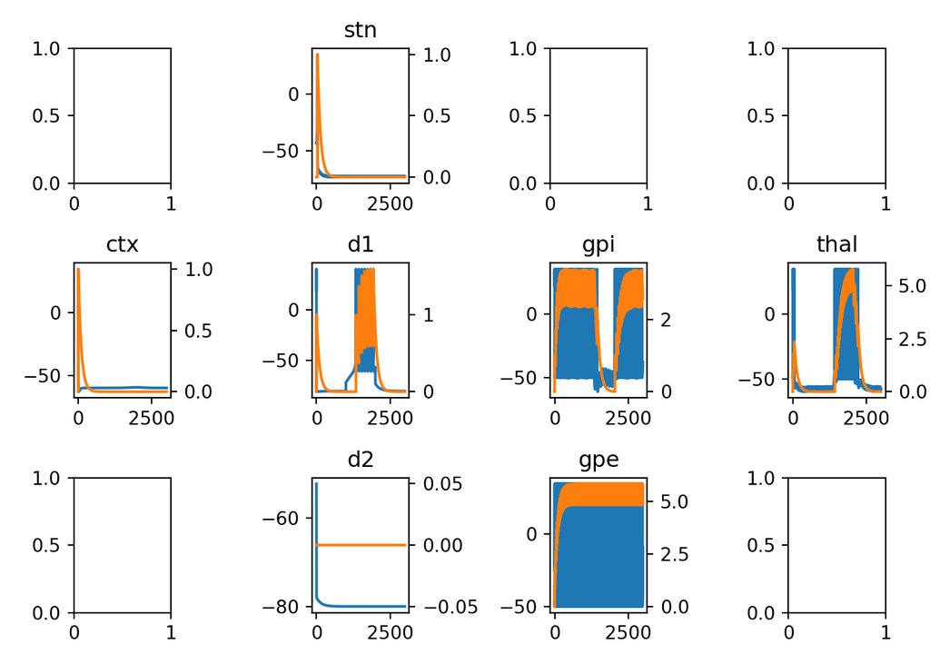

### high d1 input

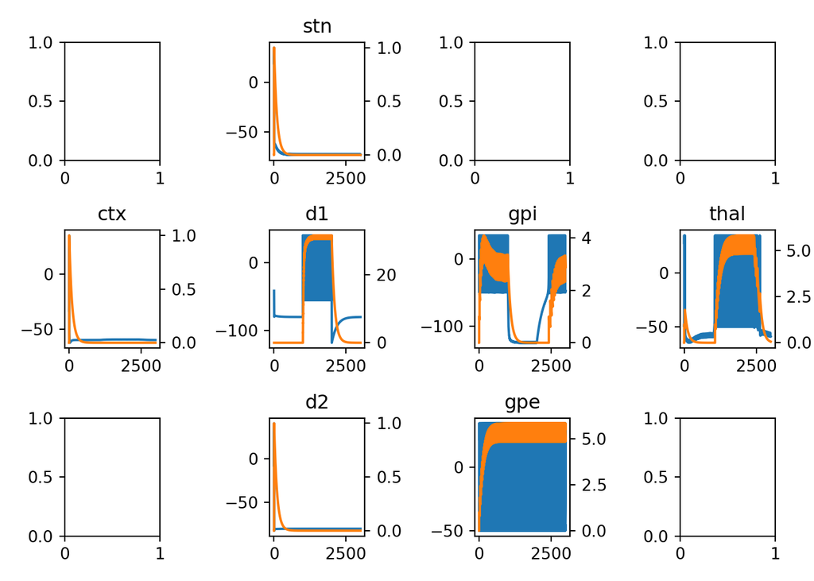

## 2

- Show that increasing drive through the indirect pathway increases inhibition of the thalamus and therefore may be seen as a ‘no-go’ pathway.

### low d2 input

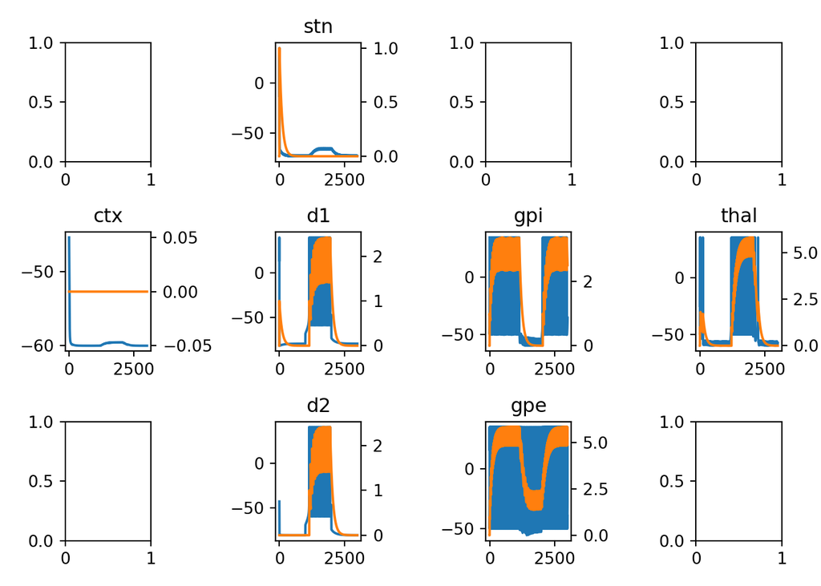

### high d2 input

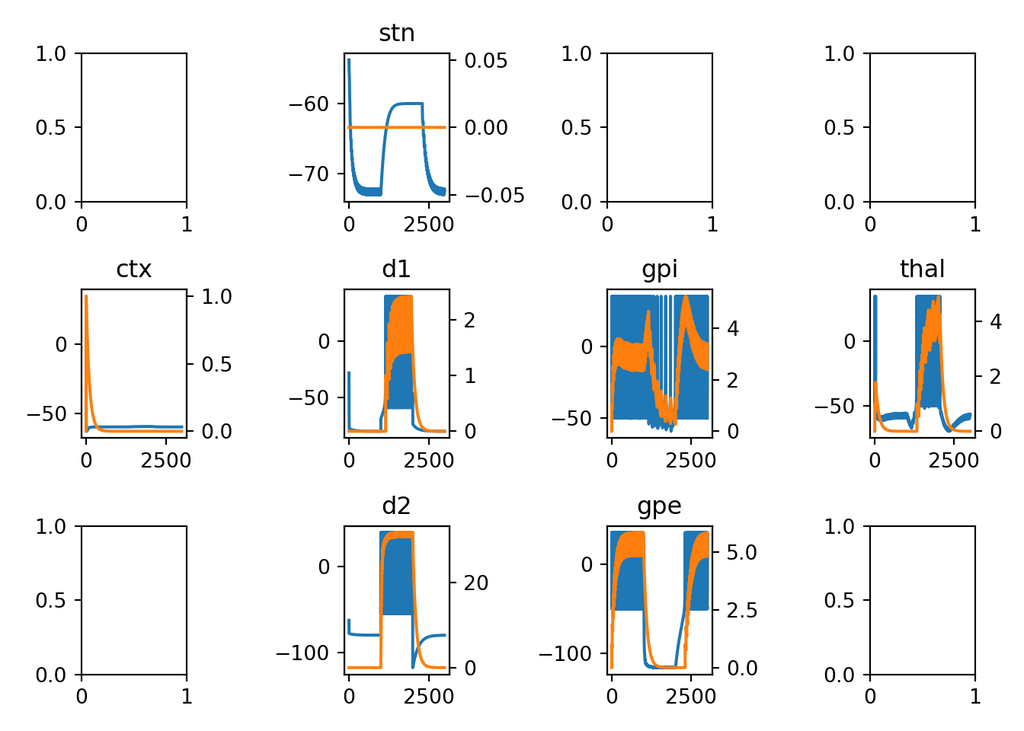

## 3

- Show that increasing drive through the hyperdirect pathway increases inhibition of the thalamus and so can also be seen as a ‘no-go’ pathway.

### low stn input

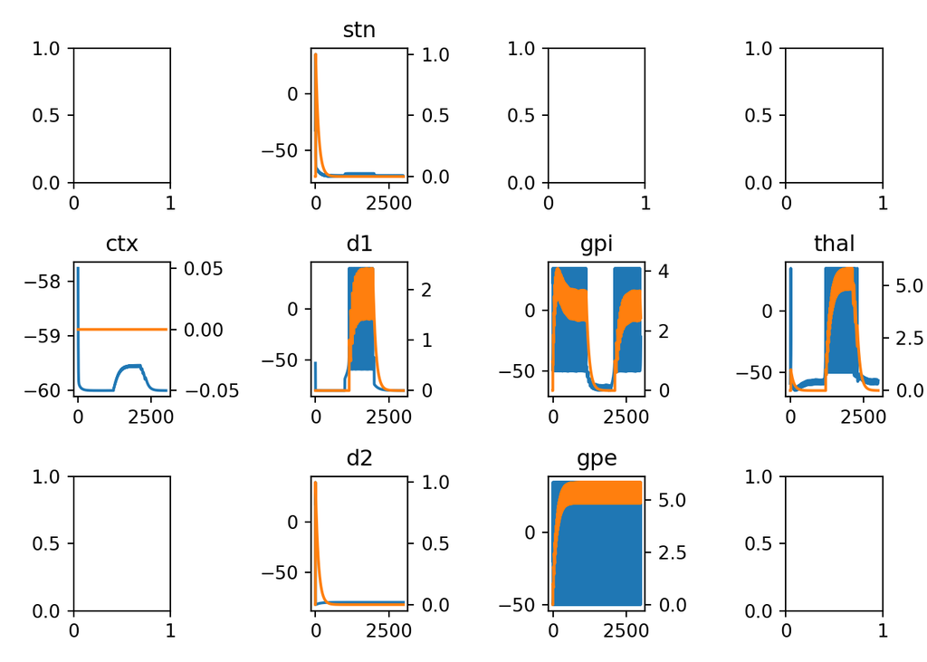

```python
# define input signal
I_in = np.zeros(n_steps)
I_in[n_steps // 3:2 * n_steps // 3] = 5e1

w_in = np.zeros(n_cells)

# add input only to d1
w_in[1] = 10
w_in[6] = 1

sim_bg(I_in, w_in)
```

### high stn input

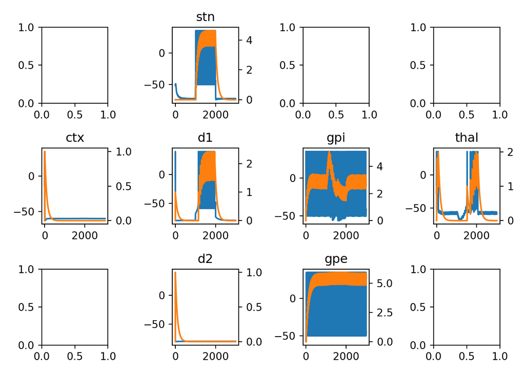

```python
# define input signal
I_in = np.zeros(n_steps)
I_in[n_steps // 3:2 * n_steps // 3] = 5e1

w_in = np.zeros(n_cells)

# add input only to d1
w_in[1] = 10
w_in[6] = 10

sim_bg(I_in, w_in)
```

## 4

- Not marked but interesting to think about: What are some key differences between the indirect and the hyperdirect pathway? Why would the basal ganglia need two ‘no-go’ pathways?

## 5

- Not marked but interesting to think about: The thalamus is merely released from inhibition. How might that lead to ‘go’ responses?